# Genome-wide methylation analysis report

# Genome-wide methylation analysis report

- study: Pleural cfDNAm analysis of femalevariable
- author: Paul Yousefi
- date: 08 October, 2026

## Parameters

```
## $sig.threshold
## [1] 2.121143e-07
##
## $max.plots
## [1] 10
##
## $qq.inflation.method
## [1] "median"
##
## $practical.threshold
## [1] 3.03101e-05
```

## Sample characteristics

For continuous or ordinal variables, the “mean” column provides the mean and the “sd/%” column the standard deviation of the variable. For categorical variables, the “mean” column provides the number of samples with the given “value” and the “sd/%” column the percentage of samples with the given “value”.

| variable | value | mean | sd.. |
| --- | --- | --- | --- |
| female |  | 0.3517915 | 0.478309 |
| sv1 |  | -1.122697e-18 | 0.0571662 |
| sv2 |  | 6.126669e-19 | 0.0571662 |
| sv3 |  | 1.034826e-18 | 0.0571662 |
| sv4 |  | -1.745674e-18 | 0.0571662 |
| sv5 |  | -4.415828e-19 | 0.0571662 |
| sv6 |  | -4.990586e-18 | 0.0571662 |
| sv7 |  | -9.502882e-19 | 0.0571662 |
| sv8 |  | 1.792186e-16 | 0.0571662 |
| sv9 |  | 4.814648e-15 | 0.0571662 |
| sv10 |  | 8.371665e-13 | 0.0571662 |

## Covariate associations

### Covariate sv1

statistics

| var1 | var2 | F | p-value | R | p-value |
| --- | --- | --- | --- | --- | --- |
| female | sv1 | 1.865489 | 0.1729989 | 0.0808945 | 0.1573848 |

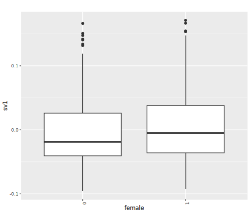

### Covariate sv2

statistics

| var1 | var2 | F | p-value | R | p-value |
| --- | --- | --- | --- | --- | --- |
| female | sv2 | 1.883578 | 0.1709365 | 0.0958265 | 0.0937333 |

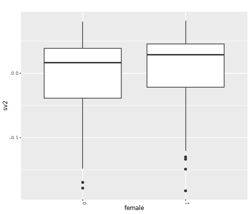

### Covariate sv3

statistics

| var1 | var2 | F | p-value | R | p-value |
| --- | --- | --- | --- | --- | --- |
| female | sv3 | 3.294079 | 0.0705122 | -0.0932865 | 0.1028053 |

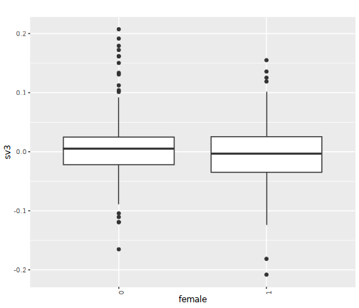

### Covariate sv4

statistics

| var1 | var2 | F | p-value | R | p-value |
| --- | --- | --- | --- | --- | --- |
| female | sv4 | 0.2761446 | 0.5996212 | -0.044719 | 0.4349584 |

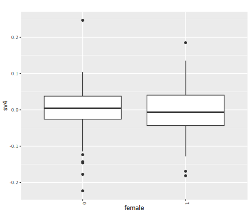

### Covariate sv5

statistics

| var1 | var2 | F | p-value | R | p-value |
| --- | --- | --- | --- | --- | --- |
| female | sv5 | 2.976519 | 0.0854937 | 0.109373 | 0.0555819 |

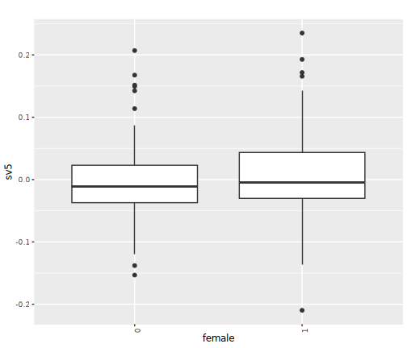

### Covariate sv6

statistics

| var1 | var2 | F | p-value | R | p-value |
| --- | --- | --- | --- | --- | --- |
| female | sv6 | 0.0683778 | 0.79389 | 0.0254768 | 0.6565799 |

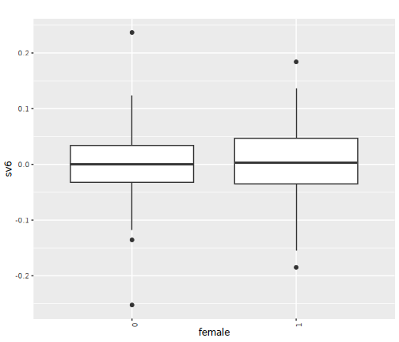

### Covariate sv7

statistics

| var1 | var2 | F | p-value | R | p-value |
| --- | --- | --- | --- | --- | --- |
| female | sv7 | 1.901193 | 0.1689553 | -0.0570341 | 0.3192249 |

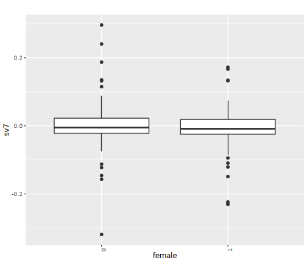

### Covariate sv8

statistics

| var1 | var2 | F | p-value | R | p-value |
| --- | --- | --- | --- | --- | --- |
| female | sv8 | 2.050043 | 0.1532258 | -0.1073718 | 0.0602353 |

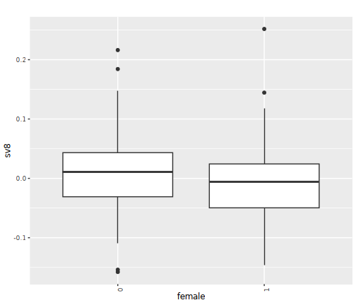

### Covariate sv9

statistics

| var1 | var2 | F | p-value | R | p-value |
| --- | --- | --- | --- | --- | --- |
| female | sv9 | 0.2881779 | 0.5917819 | -0.0436415 | 0.4461174 |

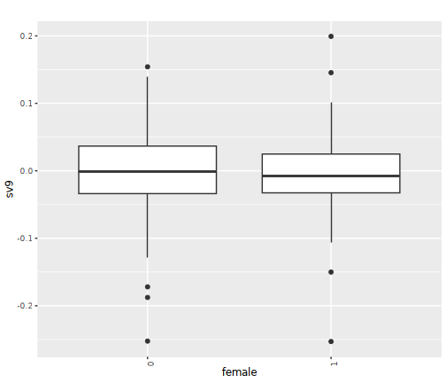

### Covariate sv10

statistics

| var1 | var2 | F | p-value | R | p-value |
| --- | --- | --- | --- | --- | --- |
| female | sv10 | 0.2842368 | 0.5943259 | 0.0366373 | 0.5224763 |

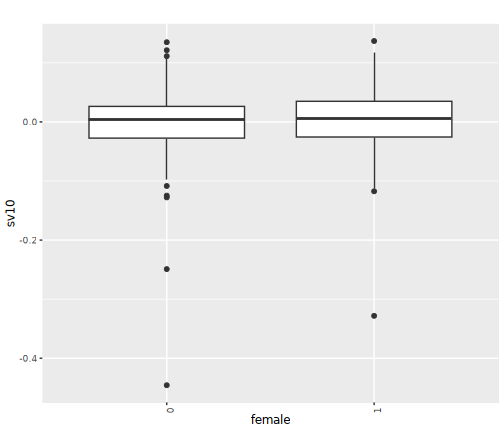

## QQ plots

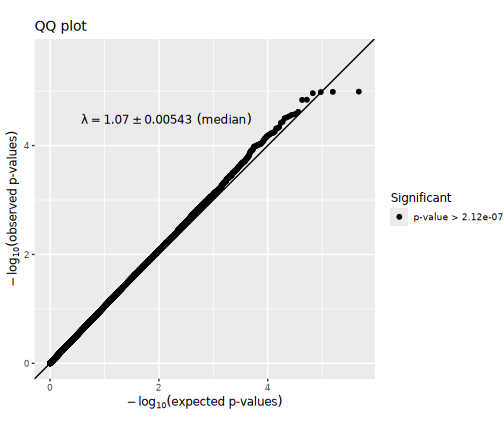

## Manhattan plots

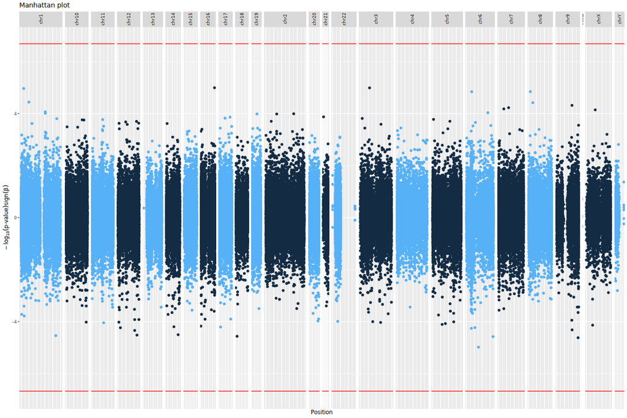

## Significant CpG sites

There were 0 CpG sites with association p-values < 2.1211427 × 10<sup>-7</sup>. These are listed in the file associations.csv.

Below are the 10 CpG sites with association p-values < 3.0310097 × 10<sup>-5</sup> in the regression model.

|  | chromosome | position | estimate | p.value | p.adjust |
| --- | --- | --- | --- | --- | --- |
| cg10449913 | chr6 | 168502784 | -0.0605880 | 2.65e-05 | 1 |
| cg09719324 | chr6 | 76059791 | -0.0744924 | 1.04e-05 | 1 |
| cg00282828 | chr1 | 15740602 | 0.0347200 | 1.09e-05 | 1 |
| cg23226544 | chr18 | 9143407 | -0.0411809 | 2.73e-05 | 1 |
| cg07177546 | chr9 | 136530014 | -0.0571723 | 2.40e-05 | 1 |
| cg03887378 | chr8 | 10131613 | 0.0577378 | 1.44e-05 | 1 |
| cg26734335 | chr16 | 87166401 | 0.0634336 | 1.02e-05 | 1 |
| cg10550816 | chr6 | 32818452 | 0.0455747 | 1.45e-05 | 1 |
| ch.3.58626439 | chr3 | 58612166 | 0.0220463 | 1.03e-05 | 1 |
| cg06811732 | chr1 | 219749669 | -0.0470033 | 2.89e-05 | 1 |

Plots of these sites follow, one for each covariate set. “p[lm]” denotes the p-value obtained using a linear model and “p[beta]” the p-value obtained using beta regression.

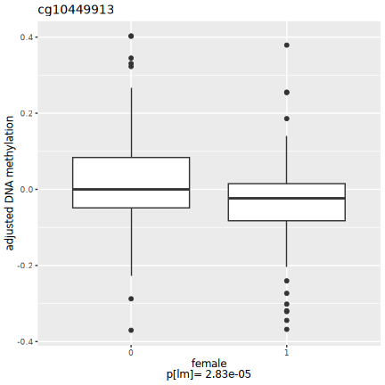

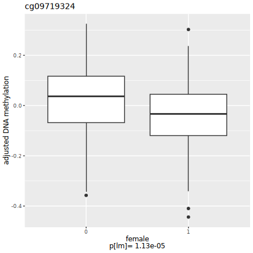

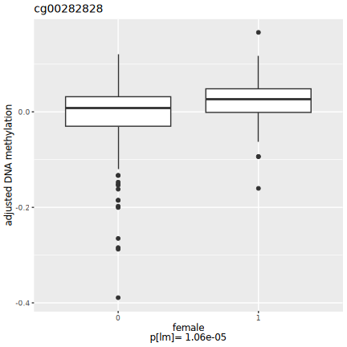

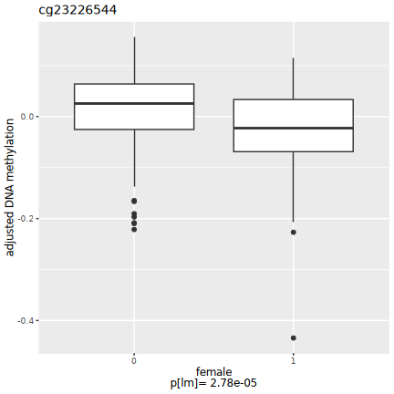

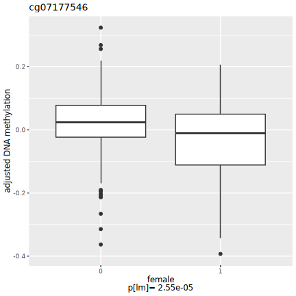

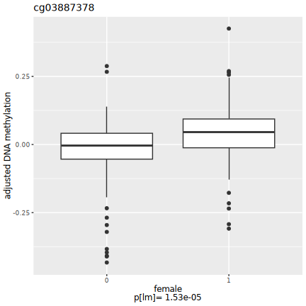

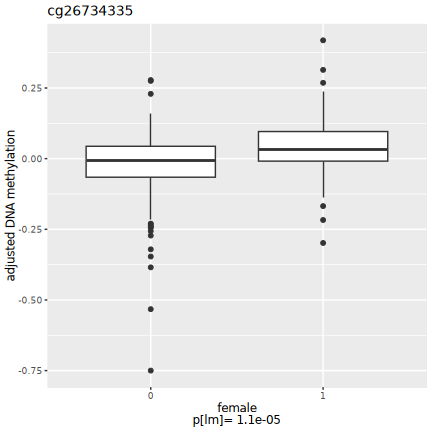

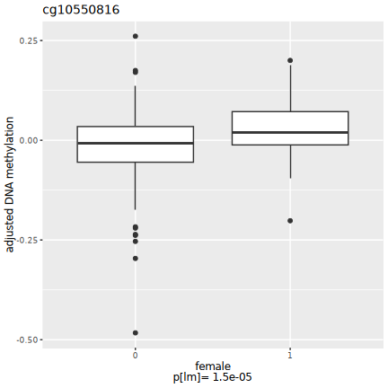

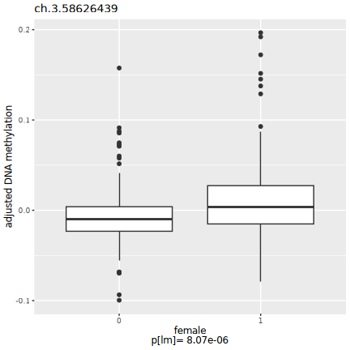

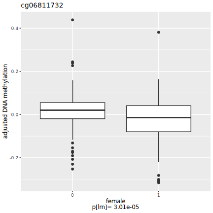

## Selected CpG sites

Number of CpG sites selected: 0.

| chromosome | position | estimate | p.value | p.adjust |
| --- | --- | --- | --- | --- |